# Reproducible Research: Peer Assessment

## global options, Import dataand set library

```r
knitr::opts_chunk$set(echo = TRUE)
```

```r
activity <- read.csv(unzip('activity.zip'))
```

```r
library(ggplot2)
```

## What is mean total number of steps taken per day?

1. Calculate the total number of steps taken per day

```r
activity_daily <- data.frame(rowsum(activity$steps, activity$date))
names(activity_daily) <- c('steps')
```

2. If you do not understand the difference between a histogram and a barplot, research the difference between them. Make a histogram of the total number of steps taken each day

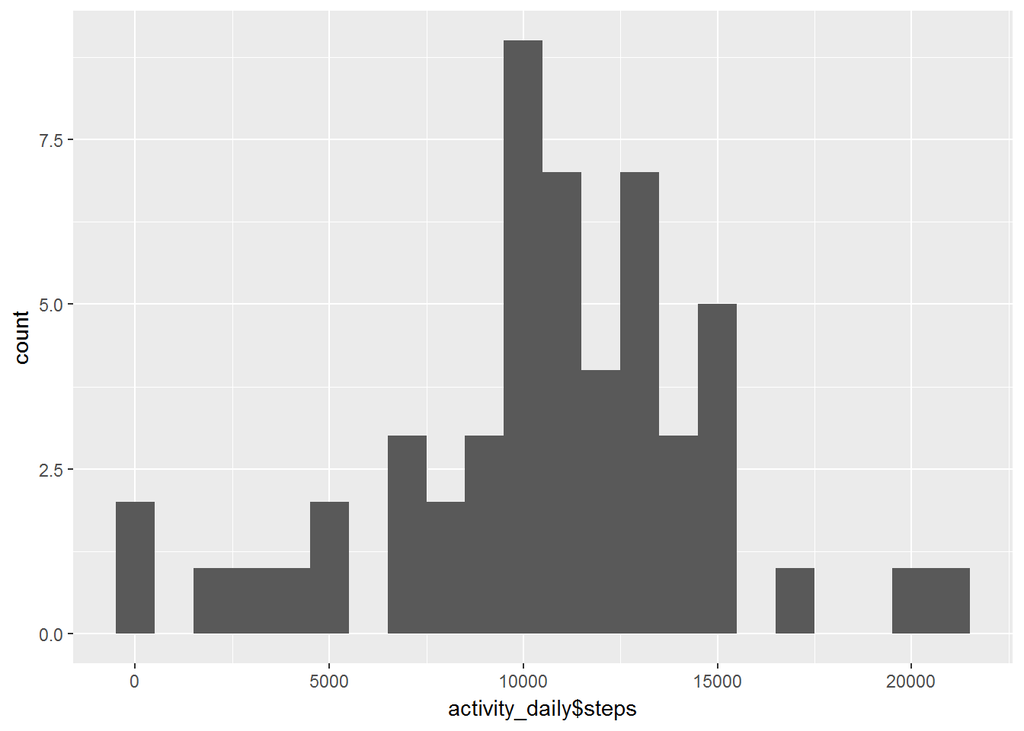

```r
qplot(activity_daily$steps, binwidth = 1000)
```

```r
activity_daily_mean <- mean(activity_daily$steps, na.rm = TRUE)
activity_daily_median <- median(activity_daily$steps, na.rm = TRUE)
```

## What is the average daily activity pattern?

1. Make a time series plot (i.e. type = “l”) of the 5-minute interval (x-axis) and the average number of steps taken, averaged across all days (y-axis)

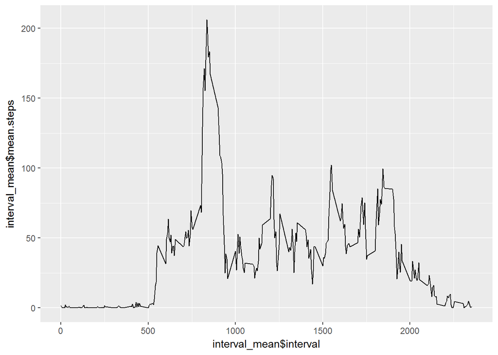

```r
interval_mean <-
  aggregate(activity$steps, list(activity$interval), mean, na.rm = TRUE)
names(interval_mean) <- c('interval', 'mean.steps')


qplot(interval_mean$interval,
      interval_mean$mean.steps,
      geom='line')
```

2. Which 5-minute interval, on average across all the days in the dataset, contains the maximum number of steps?

```r
interval <-
  interval_mean[which.max(interval_mean$mean.steps),1]
interval_step <-
  interval_mean[which.max(interval_mean$mean.steps),2]
```

**Ther interval 835 has the maximun steps 206.1698113**

## Imputing missing values

1. Calculate and report the total number of missing values in the dataset (i.e. the total number of rows with NAs)

```r
num_na <- sum(is.na(activity$steps))
```

**There are 2304 missing values.**

2. Devise a strategy for filling in all of the missing values in the dataset. The strategy does not need to be sophisticated. For example, you could use the mean/median for that day, or the mean for that 5-minute interval, etc.

**Fill the missing data with the mean of the interval.**

3. Create a new dataset that is equal to the original dataset but with the missing data filled in.

```r
activity_filled <- merge(activity, interval_mean, by='interval')
activity_filled$steps[is.na(activity_filled$steps)] <-
  as.integer(activity_filled$mean.steps[is.na(activity_filled$steps)])
```

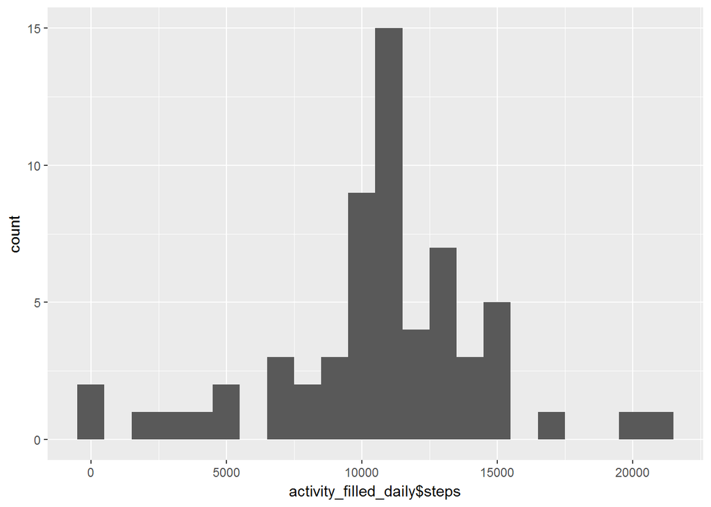

```r
activity_filled_daily <-
  data.frame(rowsum(activity_filled$steps, activity_filled$date))
names(activity_filled_daily) <- c('steps')
qplot(activity_filled_daily$steps, binwidth = 1000)
```

```r
filled_daily_mean <- mean(activity_filled_daily$steps, na.rm = TRUE)
filled_daily_median <- median(activity_filled_daily$steps, na.rm = TRUE)
```

## Are there differences in activity patterns between weekdays and weekends?

1. Create a new factor variable in the dataset with two levels – “weekday” and “weekend” indicating whether a given date is a weekday or weekend day.

```r
wknddys <- c('Saturday', 'Sunday')
activity_filled$weekday <- weekdays(as.Date(activity_filled$date))
activity_filled$daytype <- 'weekday'
activity_filled$daytype[activity_filled$weekday %in% wknddys] <- 'weekend'
activity_filled$daytype <- as.factor(activity_filled$daytype)
```

2. Make a panel plot containing a time series plot (i.e. type = “l”) of the 5-minute interval (x-axis) and the average number of steps taken, averaged across all weekday days or weekend days (y-axis). See the README file in the GitHub repository to see an example of what this plot should look like using simulated data.

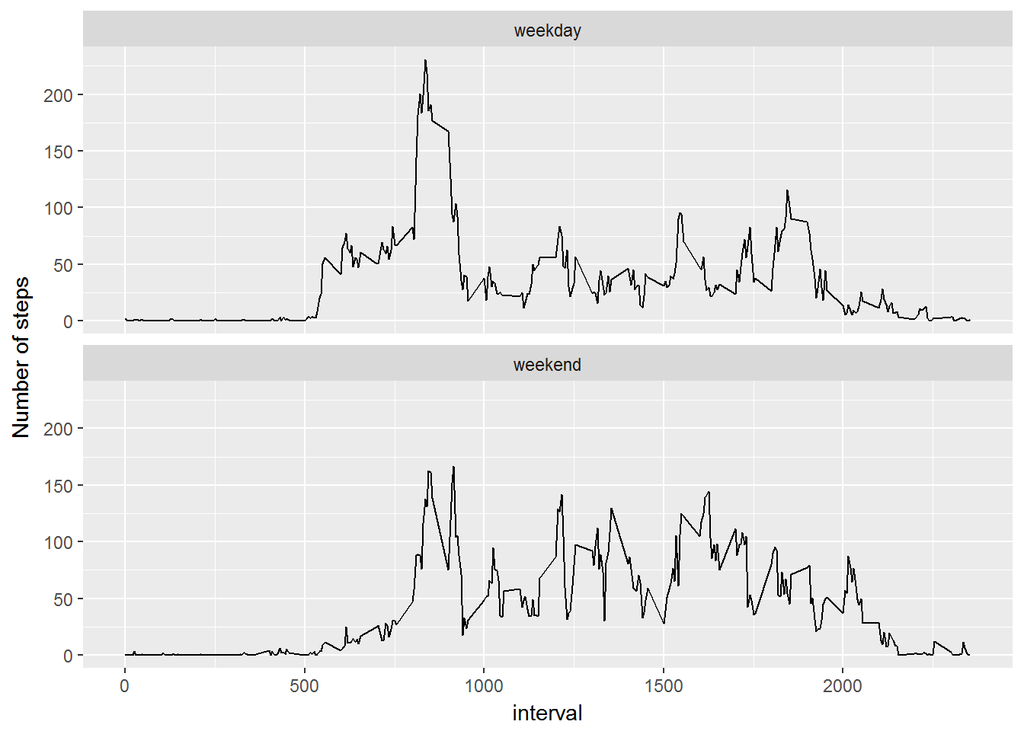

```r
steps_filled_interval <-
       aggregate(activity_filled$steps, by=list(activity_filled$daytype, activity_filled$interval), FUN=mean)
names(steps_filled_interval) <- c('daytype', 'interval', 'mean.steps')

p <- qplot(interval,
           mean.steps,
           data = steps_filled_interval,
           geom = 'line',
           ylab = 'Number of steps')
p + facet_wrap(~ daytype, ncol=1)
```